# Report

# **WITHIN-GENE SYNERGY**

The concept of bivariate synergism quantifies the combined effect of two SNPs ($A$ and $B$) on a disease ($D$) beyond their individual contributions using information theory. It is calculated as:

$Syn(A; B; D) = I(A, B; D) -[I(A; D) + I(B; D)]$

where $Syn(A; B; D)$ compares the joint contribution of SNPs $A$ and $B$ to the disease $D$ with the additive contributions of the individual SNPs. The information gain I(A; D) about the disease $D$ due to knowledge about SNP $A$ and is defined as:

$I(A; D) = H(D) - H(D|A)$  
$I(A, B; D) = H(D) - H(D|A, B)$ where $H(\cdot)$ is the entropy.  
$H(D) = \sum_d p(d)log(\frac{1}{p(d)})$  
$H(D|A) = \sum_{a,d} p(a,d)log(\frac{1}{p(d|a)})$ where $p(d)$ is the probability of having disease $D=d$ and $p(d|a)$ is the probability of having disease $D=d$ given SNP $A$ has genotype $a$.  
A Network results from the bivariate synergy calculations of each SNP where the edge of nodes $A$ and $B$ has weight $Syn(A; B; D)$.

```r
data <- fread("/Users/shane/School/CU-Denver/Masters-Project/corrected-pheno.txt")
load("/Users/shane/Library/CloudStorage/OneDrive-TheUniversityofColoradoDenver/Immunogenetics_T1D/data/complement/daisy/input/analysis_file_3levels.RData")

data <- merge(data, analysis_file, by.x = "IID", by.y = "ID")
data <- as.data.frame(data) # gets rid of data.table class



snps <- colnames(data)[21:27] # get snps
combos <- combn(snps, 2) # make combos of snps to test
self <- matrix(sort(rep(snps,2)),2) # make snpA - snpA pair to test
pairs <- matrix(c(combos,self),2) # combine combos with self rep snp pairs
syn=c()
SNP1=c()
SNP2=c()
# compute bivariate synergy between snps given pheno
for(i in 1:dim(pairs)[2]){
  snps <- pairs[,i]
  bi <- synergy(data = data, pheno = "Phenotype_discretized", snps = snps)
  SNP1 = c(SNP1, snps[1])
  SNP2 = c(SNP2, snps[2])
  syn = c(syn, bi)
}
bisyn=data.frame(SNP1,SNP2,syn)

## Make a square matrix from the dataframe of bivariate synergy
# get names for row and columns
nameVals <- sort(unique(unlist(bisyn[1:2])))
# construct 0 matrix of correct dimensions with row and column names
myMat <- matrix(0, length(nameVals), length(nameVals), dimnames = list(nameVals, nameVals))
# fill in the matrix with matrix indexing on row and column names
myMat[as.matrix(bisyn[c("SNP1", "SNP2")])] <- bisyn[["syn"]]
myMat[as.matrix(bisyn[c("SNP2", "SNP1")])] <- bisyn[["syn"]]
LD<-myMat
diag(LD) = 0 #make diagonal zero i.e no info between the same snp
# print(LD)

## Make the Diffusion Laplacian matrix
#LD<-myMat
D<-diag(rowSums(LD))
# print("D")
# print(D)
Laplacian<-as.matrix(D-LD)
print("Laplacian ===========================================")
```

```
## [1] "Laplacian ==========================================="
```

```r
print(Laplacian)
```

```
##                    chr1:196673103:G:A chr1:207131555:T:C
## chr1:196673103:G:A        0.027262524       -0.002790405
## chr1:207131555:T:C       -0.002790405        0.042547633
## chr1:207473117:G:A       -0.007995800       -0.007965451
## chr16:31265490:G:A       -0.003432930       -0.016960226
## chr19:6718376:G:C        -0.006223649       -0.008125194
## chr6:31946247:T:A        -0.001269949       -0.003471430
## chr6:31946403:G:A        -0.005549791       -0.003234928
##                    chr1:207473117:G:A chr16:31265490:G:A
## chr1:196673103:G:A       -0.007995800       -0.003432930
## chr1:207131555:T:C       -0.007965451       -0.016960226
## chr1:207473117:G:A        0.047542996       -0.009869365
## chr16:31265490:G:A       -0.009869365        0.042393646
## chr19:6718376:G:C        -0.009872686       -0.001895332
## chr6:31946247:T:A        -0.009360411       -0.001223029
## chr6:31946403:G:A        -0.002479284       -0.009012765
##                    chr19:6718376:G:C chr6:31946247:T:A
## chr1:196673103:G:A      -0.006223649     -1.269949e-03
## chr1:207131555:T:C      -0.008125194     -3.471430e-03
## chr1:207473117:G:A      -0.009872686     -9.360411e-03
## chr16:31265490:G:A      -0.001895332     -1.223029e-03
## chr19:6718376:G:C        0.030457888     -4.180800e-04
## chr6:31946247:T:A       -0.000418080      1.574839e-02
## chr6:31946403:G:A       -0.003922947     -5.486899e-06
##                    chr6:31946403:G:A
## chr1:196673103:G:A     -5.549791e-03
## chr1:207131555:T:C     -3.234928e-03
## chr1:207473117:G:A     -2.479284e-03
## chr16:31265490:G:A     -9.012765e-03
## chr19:6718376:G:C      -3.922947e-03
## chr6:31946247:T:A      -5.486899e-06
## chr6:31946403:G:A       2.420520e-02
```

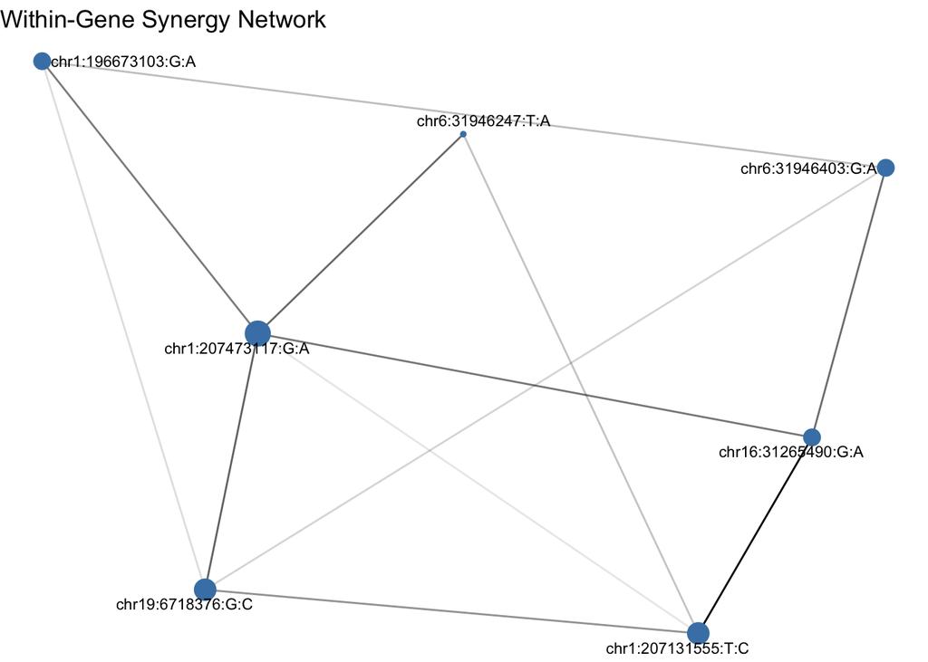

```r
gene<-density<-mean_dist<-transitivity<-edge_dens<-vertex_con<-edge_con<-NULL

############################################################
## select meaningfull edges using minet pkg and summarise graph
###########################################################

#--------------------------------------------------------------------------
# mrnet: Maximum Relevance Minimum Redundancy
graph_mrnet = mrnet(LD)

datgraph_mrnet = graph_from_adjacency_matrix(graph_mrnet,
                                             mode = "undirected",
                                             weighted = TRUE,
                                             diag = FALSE)
#remove loops
datgraph_mrnet = simplify(datgraph_mrnet,
                          remove.multiple=TRUE,
                          remove.loops=TRUE)

# gene[[file]] = file
# -----------------------------   summaries of interest
# density = edge_density(datgraph_mrnet,loop=FALSE)  #Density

# mean_dist = mean_distance(datgraph_mrnet)  #Average Path Length

# transitivity = transitivity(datgraph_mrnet)    #Clustering Coefficeint

# edge_dens = edge_density(datgraph_mrnet, loops=F) #number of edges/no.of posible edges

# vertex_con = vertex_connectivity(datgraph_mrnet) #number of edges/no.of posible edges
# edge_con = edge_connectivity(datgraph_mrnet) #number of edges/no.of posible edges

# snpbetw_centr = betweenness(datgraph_mrnet, directed=F, weights=NA)
# snpbetw_centr = data.frame(snpbetw_centr)
##dim(snpbetw_centr)
# snpsbetw_centrDF <- tibble::rownames_to_column(snpbetw_centr, "SNP")


# graphxx = data.frame(gene,density,mean_dist,transitivity,edge_dens,vertex_con,edge_con)
# graphxx = data.frame(density,mean_dist,transitivity,edge_dens,vertex_con,edge_con)



# graphxx = setNames(graphxx, c("gene", "density", "mean_dist", "transitivity", "edge_dens", "vertex_con", "edge_con"))
# graphxx = setNames(graphxx, c("density", "mean_dist", "transitivity", "edge_dens", "vertex_con", "edge_con"))


# Set node size by degree centrality
node_size <- degree(datgraph_mrnet,
                    mode = "all")

# Create a layout
graph_layout <- layout_with_fr(datgraph_mrnet)  # Force-directed layout

# Plot the network
ggraph(datgraph_mrnet, layout = graph_layout) +
  geom_edge_link(aes(edge_alpha = weight), show.legend = FALSE) +
  geom_node_point(aes(size = node_size), color = "steelblue", show.legend = FALSE) +
  geom_node_text(aes(label = name), repel = TRUE, size = 3) +
  theme_void() +
  ggtitle("Within-Gene Synergy Network")
```

# **CONCLUSION**

[figure not shown]